# Problem Set 6: Regression Discontinuity

Claire Duquennois

*Name:* Yanhao(Barney)Quan

Instructions:

- This assignment is an individual assignment. You may discuss your responses in small groups or reach out to a classmate if you are having difficulties with coding but your code and answers must reflect your individual efforts and be written using your own words. Identical assignments will be given a zero grade.
- You must post your code in a private repo on GitHub and invite Erica and I as collaborators.
- You must update your work on GitHub frequently through commits where we can observe which lines you most recently worked on when we click on the repo history. This is done very easily if you are using Git correctly which is part of what we are assessing with this assignment. Make sure you make at least five commits that highlight your most recent changes.

# 1 Empirical Analysis using Data from Manacorda, Miguel, & Vigorito (2011, American Economic Journal: Applied Economics)

This exercise uses data from Manacorda, Miguel, & Vigorito’s paper, “Government Transfers and Political Support,” published in the *American Economic Journal: Applied Economics* in 2011. This paper studies how receipt of a government anti-poverty cash transfer changes how beneficiary households support and view the government.

# 2 Finding the data

The data can be found on Edward Miguel’s faculty website. Download and extract the contents from the `Government_Transfers_replication.zip` file.

# 3 Set up and constructing the data

The original data used in the paper is confidential. The authors instead provide the `reg_panes.dta` data file which is anonymized and created from the original data.

## 3.1 Question 1: Loading the Packages

Load any R packages you will be using: **Code:**

```r
library(haven)
library(dplyr)
library(stargazer)
library(lfe)
library(tidyverse)
```

```r
library(ggplot2)
```

## 3.2 Question 2: Open the `reg_panes.dta` file. To complete this problem set you will need the following variables from this data file:

| Name | Description |
| --- | --- |
| aprobado | Ever received PANES 2005-2007 |
| untracked07 | Untracked in 2007 |
| h_89 | Supports current government 2007 [1 to 3] |
| hv34 | Supports current government 2008 [1 to 3] |
| ind_reest | Predicted Income |
| newtreat | PANES eligibility |
| geo | Geographic locality |
| bl_medad | Mean age |
| lnbl_ytoth_pc | Log per capita income |
| bl_hhsize | Mean household size |
| bl_meduc | Mean education |
| missbl_medad | Missing mean age |
| misslnbl_ytoth_pc | Missing log per capita income |
| missbl_hhsize | Missing mean household size |
| missbl_meduc | Missing mean education |
| sexo | Respondent is female |
| edad | Respondent age |
| aniosed07 | Education in 2007 |
| misssexo | Missing gender |
| missedad | Missing age |
| missaniosed | Missing education |

Drop all other variables. If needed, give the variables you are keeping more intuitive names.

**Code:**

```r
reg_panes <- read_dta("C:/Users/85384/Desktop/PS6/Government Transfers_Replication/reg_panes.dta")

data <- select(reg_panes, aprobado, untracked07, h_89, hv34, ind_reest, newtreat, geo, bl_medad, lnbl_ytoth_pc, bl_hhsize, bl_meduc, missbl_medad, misslnbl_ytoth_pc, missbl_hhsize, missbl_meduc, sexo, edad, aniosed07, misssexo, missedad,  missaniosed)
```

```r
names(data)[names(data) == 'aprobado'] <- 'received_pane05-07'
names(data)[names(data) == 'untracked07'] <- 'untracked_in_07'
names(data)[names(data) == 'h_89'] <- 'supports_current_gov07'
names(data)[names(data) == 'hv34'] <- 'supports_current_gov08'
names(data)[names(data) == 'ind_reest'] <- 'predicted_income'
names(data)[names(data) == 'newtreat'] <- 'pane_eligibility'
names(data)[names(data) == 'geo'] <- 'geographic_locality'
names(data)[names(data) == 'bl_medad'] <- 'mean_age'
names(data)[names(data) == 'lnbl_ytoth_pc'] <- 'log_per_capita_income'
names(data)[names(data) == 'bl_hhsize'] <- 'mean_household_size'
names(data)[names(data) == 'bl_meduc'] <- 'mean_education'
names(data)[names(data) == 'missbl_medad'] <- 'missing_mean_age'
names(data)[names(data) == 'misslnbl_ytoth_pc'] <- 'missing_log_per_capita_income'
names(data)[names(data) == 'missbl_hhsize'] <- 'missing_mean_household_size'
names(data)[names(data) == 'missbl_meduc'] <- 'missing_mean_education'
names(data)[names(data) == 'sexo'] <- 'respondent_is_female'
names(data)[names(data) == 'edad'] <- 'respondent_age'
names(data)[names(data) == 'aniosed07'] <- 'education_in_07'
names(data)[names(data) == 'misssexo'] <- 'missing_gender'
names(data)[names(data) == 'missedad'] <- 'missing_age'
names(data)[names(data) == 'missaniosed'] <- 'missing_education'
View(data)
```

## 3.3 **Question 3: The data as downloaded will require that you clean the variables of interest and construct a new dataset to generate the graphs. Start by generating the following cleaned variable:**

-An indicator for receiving PANES that is NA if a respondent is untracked in 2007

**Code:**

```r
data$rev_panes <- ifelse(data$untracked_in_07 == 0, "NA", data$`received_pane05-07`)
View(data)
```

## 3.4 **Question 4: We are going to re-scale the variables that indicate support for the current government so that responses range from 0 to 1. To do this, tabulate the current variable to see how it is distributed and then generate a variable that will be NA if it is currently coded as 9, 0 if currently 2, 0.5 if currently 1 and 1 if currently 3. Do this for both the 2007 and 2008 variable.**

Note: This is how the authors modify this variable in their code. It seems counter intuitive and does not correspond to the description of how this variable is coded in the survey questionnaire as reported in their appendix though it does correspond to their discussion in footnote 12. My guess is the transcription/translation of the survey question is incorrect.

**Code:**

```r
data$sup07 <- 0
for (supports_current_gove07 in data) {
data$sup07 <- ifelse(data$supports_current_gov07 == 9, NA, data$sup07)
data$sup07 <- ifelse(data$supports_current_gov07 == 2, 0, data$sup07)
data$sup07 <- ifelse(data$supports_current_gov07 == 1, 0.5, data$sup07)
data$sup07 <- ifelse(data$supports_current_gov07 == 3, 1, data$sup07)
}
table(data$sup07)
```

```
##
##    0  0.5    1
##  122  397 1570
```

```r
data$sup08 <- 0
for (supports_current_gov08 in data) {
data$sup08 <- ifelse(data$supports_current_gov08 == 9, NA, data$sup08)
data$sup08 <- ifelse(data$supports_current_gov08 == 2, 0, data$sup08)
data$sup08 <- ifelse(data$supports_current_gov08 == 1, 0.5, data$sup08)
data$sup08 <- ifelse(data$supports_current_gov08 == 3, 1, data$sup08)
}
table(data$sup08)
```

```
##
##    0  0.5    1
##  159  476 1313
```

```r
#View(data)
```

## 3.5 **Question 5: Generate a variable that is the square of predicted income.**

**Code:**

```r
data$predicted_income_sqrd <- data$predicted_income * data$predicted_income
#View(data)
```

# 4 We start by reproducing the main figures (2,3,and 4) of the paper as good figures are key to any regression discontinuity paper.

## 4.3 **Question 8: Replicating these figures will require restructuring our data and calculating the values that are plotted. Generate a variable that will indicate the percentile group the observation is in. Note the difference in the number of percentile groups above and below the threshold.**

Note: you may find the `xtile` function in R useful.

**Code:**

```r
library(statar)
data$bins1 <- NA
data$bins1[data$predicted_income < 0] <- xtile(data$predicted_income[data$predicted_income < 0], n=30)
data$bins2 <- NA
data$bins2[data$predicted_income >= 0] <- xtile(data$predicted_income[data$predicted_income >= 0], n=15)
data$bins2 <- data$bins2 + 30
data$bins1[data$predicted_income >= 0] <- data$bins2[data$predicted_income >= 0]
View(data)
```

## 4.4 **Question 9: For each of the percentile groups, calculate the mean of each of the variables we will use for plotting: predicted income, receipt of PANES, support for the government in 2007, and support for the government in 2008.**

**Code:**

```r
data_mean<-data %>%
  group_by(bins1) %>%
dplyr::summarize(prebinmean = mean(predicted_income, na.rm=TRUE),
                 treatbinmean = mean(`received_pane05-07`, na.rm=TRUE), sup07binmean=mean(sup07, na.rm=TRUE),
sup08binmean=mean(sup08, na.rm=TRUE), numb=n())
View(data_mean)
```

## 4.5 **Question 10: Replicate figure 2. Make the figure as clear and informative as possible. You may want to create an indicator variable for percentiles above and below the threshold.**

**Code:**

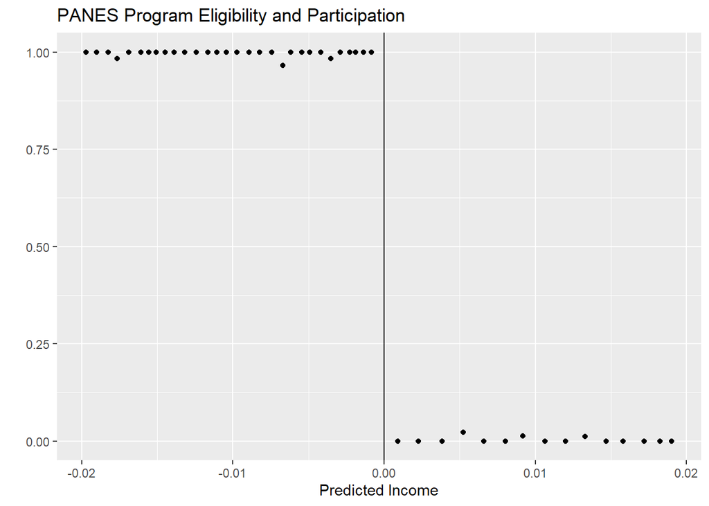

```r
data_mean$bins1 <- as.numeric(as.character(data_mean$bins1))
plot1 <- ggplot(data_mean, aes(x=prebinmean, y=treatbinmean)) + geom_point()+geom_vline(xintercept = 0) + ylab("")+xlab("Predicted Income") + ggtitle("PANES Program Eligibility and Participation")
plot1
```

## 4.6 **Question 11: What is the purpose of this figure and what should we take away from it?**

**Answer:The purpose of the RD design is that the treatment assignment rule is known (or at least partially known). We should therefore be able to see discontinuous changes in the treatment and the outcome (if there is an e˙ect) as the running variable crosses the threshold, so the figure here is to visualize the discontinuous changes. The figure demonstrates that program implementation was remarkably clean; among applicants, practically all potential beneficiaries—i.e., those with a standardized predicted income score below zero—benefited from the program. The opposite holds for ineligible households, and the discontinuity in the probability of program receipt at the threshold is 99 percentage points. This implies that enforcement of the rule was nearly as strict as implied by the letter of the law.**

## 4.7 **Question 12: Replicate figures 3 and 4. Make these figures as clear and informative as possible.**

**Code:**

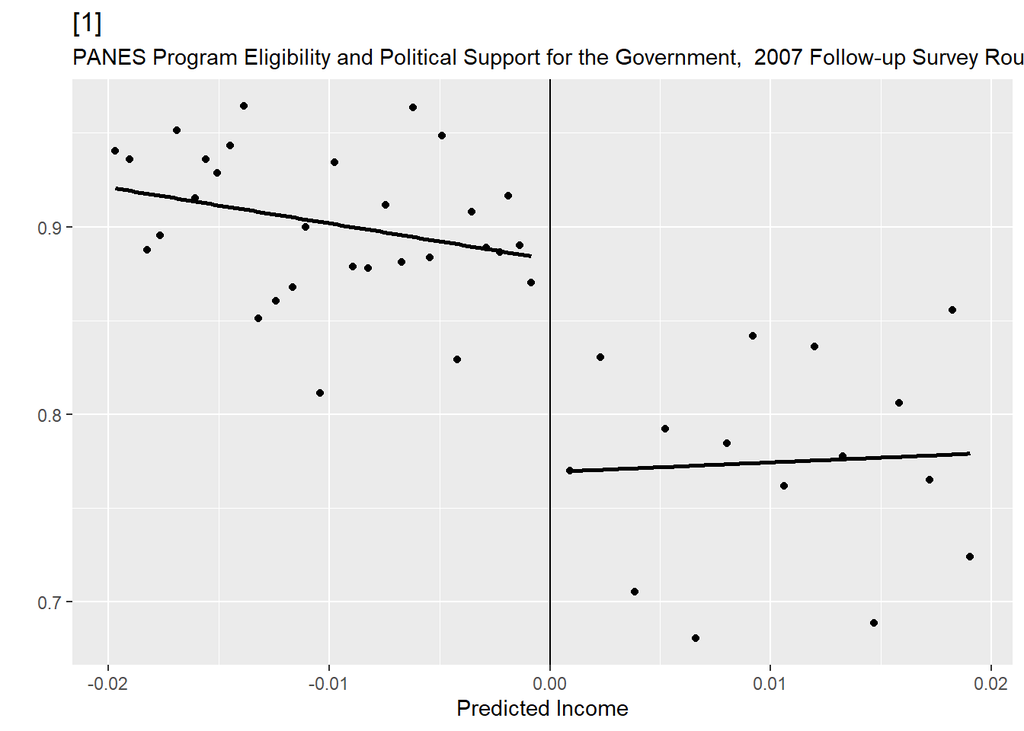

```r
data_mean2 <- data_mean %>% filter(bins1 <= 30)
data_mean3 <- data_mean %>% filter(bins1 > 30)
#View(data_mean2)
#View(data_mean3)
plot2 <- ggplot() +
  geom_point(data_mean2, mapping = aes(x=prebinmean, y=sup07binmean)) + geom_smooth(data_mean2, mapping = aes(x=prebinmean, y=sup07binmean), method = lm, se = FALSE, color = "Black")+
  geom_point(data_mean3, mapping = aes(x=prebinmean, y=sup07binmean)) + geom_smooth(data_mean3, mapping = aes(x=prebinmean, y=sup07binmean), method = lm, se = FALSE, color = "Black")+
  geom_vline(xintercept = 0) + ylab("")+xlab("Predicted Income") + ggtitle(size_sum(0.5), "PANES Program Eligibility and Political Support for the Government,  2007 Follow-up Survey Round")
plot2
```

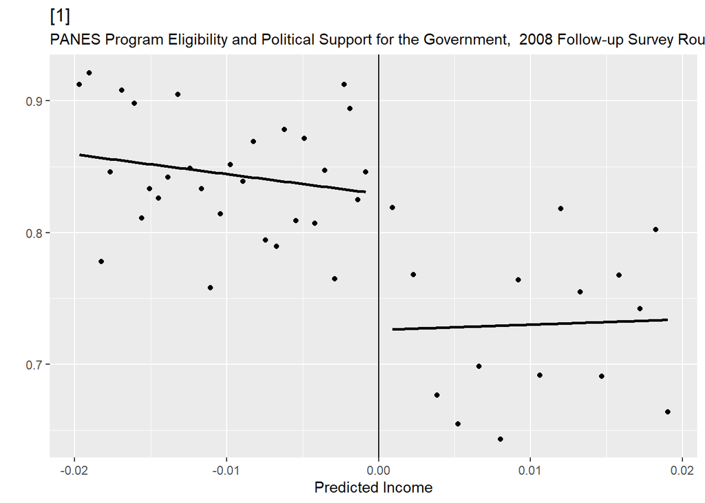

```r
plot3 <- ggplot() +
  geom_point(data_mean2, mapping = aes(x=prebinmean, y=sup08binmean)) + geom_smooth(data_mean2, mapping = aes(x=prebinmean, y=sup08binmean), method = lm, se = FALSE, color = "Black")+
  geom_point(data_mean3, mapping = aes(x=prebinmean, y=sup08binmean)) + geom_smooth(data_mean3, mapping = aes(x=prebinmean, y=sup08binmean), method = lm, se = FALSE, color = "Black")+
  geom_vline(xintercept = 0) + ylab("")+xlab("Predicted Income") + ggtitle(size_sum(0.5), "PANES Program Eligibility and Political Support for the Government,  2008 Follow-up Survey Round")
plot3
```

## 4.9 **Question 14: Replicate the results of the three regressions estimated in the first column of table 1. Present your results in a table. Interpret the coefficients.**

**Code:**

**PANES Program Eligibility, Participation, and Political Support for the Government**

|  | *Dependent variable:* |  |  |
| --- | --- | --- | --- |
|  | Ever received PANES, 2005–2007 | Government support, 2007 (during program) | Government support, 2008 (post-program) |
|  | (1) | (2) | (3) |
| Indicator (Standard Errors) | 0.993*** | 0.129*** | 0.118*** |
|  | (0.002) | (0.013) | (0.015) |
| Constant | 0.004** | 0.772*** | 0.728*** |
|  | (0.002) | (0.011) | (0.012) |
| Observations | 2,232 | 2,089 | 1,948 |
| R<sup>2</sup> | 0.987 | 0.050 | 0.034 |
| Adjusted R<sup>2</sup> | 0.987 | 0.049 | 0.033 |
| Residual Std. Error | 0.056 (df = 2230) | 0.280 (df = 2087) | 0.313 (df = 1946) |
| *Note:* | p<0.1; p<0.05; p<0.01 |  |  |

## 4.10 **Question 15: Write down the specifications used in row 2 of columns 1,2 and 3 of table 1.**

**Answer: Columns 1–3 include, in order, a polynomial in the standardized score of degree 0, 1, and 2, and these polynomials interacted with the eligibility indicator.**

## 4.11 **Question 16: Replicate all of the results reported in row 2 of Table 1. Explain the difference between these specifications and interpret their coefficients.**

Hint: the variables listed in the table above after newtreat are the controls you will want to include.

**Code:**

**PANES Program Eligibility, Participation, and Political Support for the Government**

|  | Government support, 2007 (during program) |  |  |  |  |  |
| --- | --- | --- | --- | --- | --- | --- |
|  | (1) | (2) | (3) | (4) | (5) | (6) |
| Indicator (Standard Errors) | 0.129*** | 0.110*** | 0.130*** | 0.132*** | 0.108*** | 0.133*** |
|  | (0.013) | (0.026) | (0.040) | (0.013) | (0.026) | (0.041) |
| Predicted Income |  | -0.011 | 0.812 |  | -0.275 | 0.582 |
|  |  | (1.969) | (7.805) |  | (1.968) | (7.833) |
| Predicted Income sqrd |  |  | -40.457 |  |  | -41.873 |
|  |  |  | (375.496) |  |  | (376.894) |
| Indicator*Predicted Income |  | -1.916 | 2.377 |  | -1.742 | 3.718 |
|  |  | (2.221) | (9.244) |  | (2.221) | (9.320) |
| Indicator*Predicted Income sqrd |  |  | 292.215 |  |  | 352.682 |
|  |  |  | (442.276) |  |  | (445.158) |
| Constant | 0.772*** | 0.772*** | 0.769*** | 0.781*** | 0.779*** | 0.775*** |
|  | (0.011) | (0.023) | (0.034) | (0.031) | (0.035) | (0.045) |
| Score controls | None | Linear | Quadratic | None | Linear | Quadratic |
| Other controls | No | No | No | Yes | Yes | Yes |
| *N* | 2,089 | 2,089 | 2,089 | 2,089 | 2,089 | 2,089 |
| R<sup>2</sup> | 0.050 | 0.051 | 0.051 | 0.055 | 0.056 | 0.056 |
| Adjusted R<sup>2</sup> | 0.049 | 0.049 | 0.049 | 0.050 | 0.051 | 0.050 |
| Residual Std. Error | 0.280 (df = 2087) | 0.280 (df = 2085) | 0.280 (df = 2083) | 0.280 (df = 2078) | 0.280 (df = 2077) | 0.280 (df = 2075) |
| Significance Levels | ***Significant at the 1 percent level. |  |  |  |  |  |
|  | **Significant at the 5 percent level. |  |  |  |  |  |
|  | *Significant at the 10 percent level. |  |  |  |  |  |

**Answer: For the first three column, we have already explained above, for column 4-6, additionally control for pretreatment char-acteristics of household members, log per-capita income, age, education, and gender of the household head, locali-dad indicators, and separate indicators for missing values of each of these variables. In row 2 of the Table, the dependent variable is political support for the government in the first follow-up survey in 2007. Here, we use observations with valid responses o the political support variable, reducing the sample slightly. All estimates are of similar magnitude and statistically significant, suggesting a higher level of support for the government—of between 11 and 13 percentage points—among those eligible for PANES.**

## 4.12 **Question 17: What is the point of including all of these specifications?**

**Answer: The point of including all of these specification is to give the reader a better view of how they design the test and how they thinking trough the problems, when the graph and table become complicated, then these specification could give a better sense of what the graph and table is showing there.**

## 4.13 **Question 18: Using the coefficients estimated above, write out the function you would use to predict the probability a household supports the current government based on their predicted income score:**

**b) If they are not eligible for the transfer using the results from column 1.**
$$0.772$$
**c) If they are eligible for the transfer using the results from column 2.**
$$sup07 = 0.772+0.110*indicator-0.011*Predicted Income-1.916 *Indicator*Predicted Income$$

**d) If they are not eligible for the transfer using the results from column 2.**
$$sup07=0.772-0.011Predicted Income$$

**e) If they are eligible for the transfer using the results from column 3.**
$$sup07=0.769 + 0.130*Indicator + 0.812*Predicted Income-40.457*Predicted Income Sqrd+2.377*Indicator*Predicted Income+292.215*Indicator*Predicted Income sqrd$$

**f) If they are not eligible for the transfer using the results from column 3.**

**Answer:**
$$sup07=0.769 + 0.812*Predicted Income-40.457*Predicted Income Sqrd$$

## 4.14 **Question 19: How narrow is the “bandwidth” used by the authors. Why does this matter? Check that the results are robust to a narrower bandwidth.**

**Code:**

```r
band_data <- filter(data, data$predicted_income < 0.01)
band_data <- filter(data, data$predicted_income > -0.01)
View(band_data)
```

**PANES Program Eligibility, Participation, and Political Support for the Government**

[output not shown]

## 4.17 **Question 22: Was this threshold eligibility score specifically designed for this particular program? Why does this matter?**

**Answer: Yes, the true eligibility threshold provides the best fit to the data as measured by the regression, providing reassurance that the discontinuity we exploit is a genuine feature of the data. As an additional robustness check, we take advantage of the fact that the PANES eligibility threshold differs slightly across Uruguayan regions to estimate a difference-in-differences model, conditioning on the un-standardized income score and regional fixed effects, and focusing on the coefficient estimate on an indicator for PANES eligibility in that region.**

# 5 Submission instructions:

1. Make sure the final version of your assignment is uploaded on GitHub in both html and Rmarkdown format.